# Practice Final Exam

Week 11, Regression I, Fall 2026

> **This practice exam mirrors the real final exam’s format, length, and difficulty: 20 points, 90 minutes, same four parts.** Take it under exam conditions (printed or handwritten notes, textbook, calculator, no other electronic devices, no AI). Answers are discussed in the Week 11 review session.

**Time allowed: 90 minutes.** Total: **20 points**.

**Permitted materials:** printed or handwritten notes, the textbook, and a calculator. **Not permitted:** any other electronic device (laptop, tablet, phone, or smartwatch) and no AI tools of any kind.

Answer every interpretation question in complete sentences, in context, with units. You never need to run R; every question can be answered from the output and figures printed here.

Name: ________________________________ NYU NetID: ______________

**Honor statement.** I affirm that the work on this exam is entirely my own and that I have used only the permitted materials listed above.

Signature: ________________________________ Date: ______________

# Part 1: Reading R output (8 points)

Researchers measured lung function in a community sample of $n = 150$ adults. Variables:

| Variable | Meaning |
| --- | --- |
| `fev` | forced expiratory volume in 1 second, in liters |
| `age` | age, in years |
| `height` | standing height, in centimeters |
| `smoker` | current smoker (`yes`/`no`; reference level `no`) |

The analyst fit `f1 <- lm(fev ~ age + height + smoker, data = lung)` and obtained:

```r
summary(f1)
```

```
Call:
lm(formula = fev ~ age + height + smoker, data = lung)

Residuals:
     Min       1Q   Median       3Q      Max
-1.33369 -0.29622  0.05989  0.24929  1.12804

Coefficients:
             Estimate Std. Error t value Pr(>|t|)
(Intercept) -2.892650   0.663746  -4.358 2.46e-05 ***
age         -0.031930   0.002622 -12.176  < 2e-16 ***
height       0.049478   0.003853  12.843  < 2e-16 ***
smokeryes   -0.388633   0.075950  -5.117 9.62e-07 ***
---
Signif. codes:  0 '***' 0.001 '**' 0.01 '*' 0.05 '.' 0.1 ' ' 1

Residual standard error: 0.4314 on 146 degrees of freedom
Multiple R-squared:  0.6946,    Adjusted R-squared:  0.6883
F-statistic: 110.7 on 3 and 146 DF,  p-value: < 2.2e-16
```

**1.1 (1 point).** Interpret the coefficient of `age` in one precise sentence, in context, with units, including what is held fixed.

**1.2 (1 point).** Interpret the coefficient of `smokeryes` in one precise sentence. Your sentence must make clear which group is being compared to which.

**1.3 (1 point).** Interpret the intercept estimate of -2.89 liters. Is it a scientifically meaningful quantity here? Why or why not, and why do we keep it in the model anyway?

**1.4 (1 point).** The output reports Multiple R-squared = 0.69. State in one sentence what this number means here, then explain whether an $R^2$ this large tells us the model is correct or that these predictors causally determine lung function.

**1.5 (1 point).** The analyst then ran:

```r
round(confint(f1), 4)
```

```
              2.5 %  97.5 %
(Intercept) -4.2044 -1.5809
age         -0.0371 -0.0267
height       0.0419  0.0571
smokeryes   -0.5387 -0.2385
```

Interpret the 95% confidence interval for `height` in one precise sentence, and state what this interval implies about the two-sided test of $H_0: \beta_{\texttt{height}} = 0$ at level 0.05.

**1.6 (1.5 points).** To ask whether `age` and `smoker` add anything beyond `height`, the analyst compared nested models:

```r
f0 <- lm(fev ~ height, data = lung)
anova(f0, f1)
```

```
Analysis of Variance Table

Model 1: fev ~ height
Model 2: fev ~ age + height + smoker
  Res.Df    RSS Df Sum of Sq      F    Pr(>F)
1    148 60.330
2    146 27.172  2    33.158 89.083 < 2.2e-16 ***
---
Signif. codes:  0 '***' 0.001 '**' 0.01 '*' 0.05 '.' 0.1 ' ' 1
```

State the null and alternative hypotheses of this F test (symbols or words), then give the conclusion at level 0.05 in context.

**1.7 (1.5 points).** For a new patient with `age` = 45, `height` = 172, and `smoker` = `no`, the analyst computed both intervals:

```r
new_pt <- data.frame(age = 45, height = 172, smoker = "no")
round(predict(f1, new_pt, interval = "confidence"), 2)
```

```
   fit lwr  upr
1 4.18 4.1 4.27
```

```r
round(predict(f1, new_pt, interval = "prediction"), 2)
```

```
   fit  lwr  upr
1 4.18 3.32 5.04
```

1. Explain, in this context, what each of the two intervals is an interval *for*. (b) A pulmonologist wants a plausible range for *this patient’s* FEV measurement. Which interval applies? (c) Explain why that interval is so much wider than the other one.

# Part 2: Diagnostics (6 points)

An analyst fit two simple linear regressions in a clinical study:

- **Model C:** serum biomarker concentration (ng/mL) on drug dose (mg), $n = 90$ participants.
- **Model D:** C-reactive protein (mg/L) on BMI (kg/m$^2$), $n = 90$ participants.

Each model’s residuals-vs-fitted plot and normal Q-Q plot are shown below.

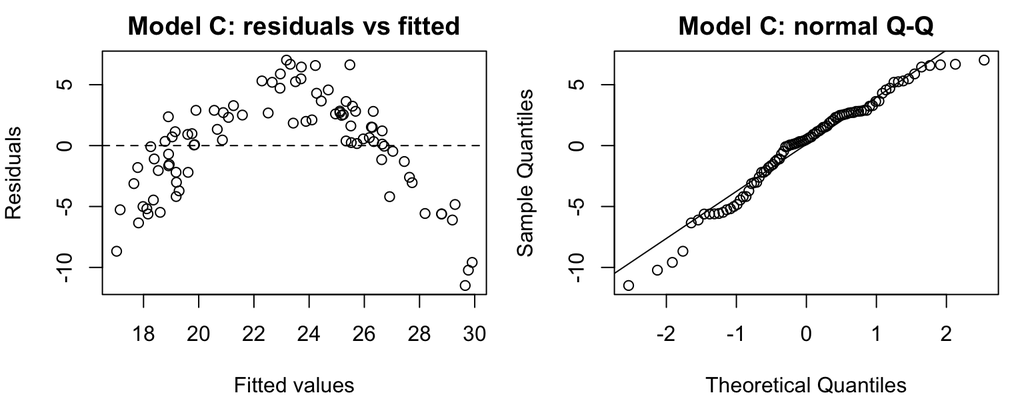

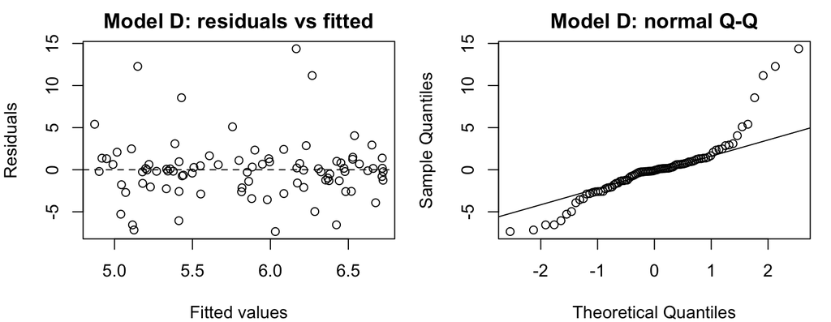

**2.1 (2 points).** For **Model C**, using its residuals-vs-fitted plot: (a) name the regression assumption that is violated and describe the visual evidence (1 point); (b) state one consequence of this violation for the analysis and prescribe one specific remedy (1 point).

**2.2 (2 points).** For **Model D**, using its normal Q-Q plot: (a) name the assumption that is violated and describe the shape of the violation (1 point); (b) state which parts of the analysis this threatens most and prescribe one specific remedy or follow-up check (1 point).

**2.3 (2 points).** A model of fasting glucose with $p = 2$ predictors was fit to $n = 80$ patients, so the average leverage is $(p + 1)/n \approx 0.038$. Four observations are summarized below.

| Observation | Leverage $h_i$ | Studentized residual | Cook’s distance |
| --- | --- | --- | --- |
| 1 | 0.05 | 2.2 | 0.08 |
| 2 | 0.35 | $-0.3$ | 0.02 |
| 3 | 0.30 | $-3.0$ | 1.29 |
| 4 | 0.04 | 0.8 | 0.01 |

1. Which single observation is most influential on the fitted coefficients? Justify using both its leverage and its residual (1 point). (b) Observation 2 has the highest leverage in the table, yet its Cook’s distance is tiny. Explain how an observation can have high leverage but little influence (1 point).

# Part 3: Concepts (4 points)

Eight multiple-choice questions, 0.5 points each. Circle exactly one answer per question.

**3.1.** An observational study finds that adults who drink three or more cups of coffee per day have higher lung cancer rates. Which is the best reason to doubt the claim “coffee causes lung cancer”?

1. Coffee consumption is too hard to measure accurately.
2. Heavy coffee drinkers are more likely to be smokers, and smoking causes lung cancer, so smoking can produce this association without any effect of coffee.
3. Lung cancer is too rare for regression methods.
4. The claim would require a randomized trial of lung cancer.

**3.2.** A health department identifies the ten clinics with the worst patient-satisfaction scores this year and sends them an intervention team. Next year, those clinics’ scores improve. Before crediting the intervention, you should first consider:

1. That satisfaction surveys are always biased.
2. That the intervention teams coached clinics on the survey.
3. That patient populations changed between years.
4. Regression to the mean: clinics selected for extreme low scores would tend to score closer to average the next year even with no intervention.

**3.3.** In a model of blood pressure, daily sodium intake in milligrams has slope 0.002. The analyst refits with sodium in grams. Which is true of the refit?

1. The slope becomes 2, its standard error is multiplied by 1000, and the t statistic, p-value, and $R^2$ are unchanged.
2. The slope becomes 0.000002 and the model fits worse.
3. The slope becomes 2 and the p-value becomes smaller.
4. The slope and all inference are unchanged.

**3.4.** A model of lung function includes both height and arm span, which have correlation 0.97. The most likely consequence is:

1. The residuals become skewed.
2. The coefficient estimates become biased.
3. The standard errors of the height and arm span coefficients become large, and the two estimated coefficients can be unstable, even though predictions can remain good.
4. $R^2$ becomes negative.

**3.5.** In `lm(bp_sys ~ smoker + age)`, `smoker` is a factor with levels `never` (reference), `former`, `current`. The estimated coefficient of `smokercurrent` is 4.1. This means:

1. Comparing people of the same age, current smokers average 4.1 mmHg higher systolic blood pressure than never smokers.
2. Current smokers average 4.1 mmHg higher than former smokers.
3. Current smokers average 4.1 mmHg above the overall sample mean.
4. Smoking raises blood pressure by 4.1 mmHg per cigarette.

**3.6.** Comparing model selection with AIC versus BIC on the same candidate set, which is correct?

1. They always agree for linear models.
2. BIC tends to select larger models than AIC.
3. AIC tends to select larger models than BIC, because BIC’s per-parameter penalty is heavier at the sample sizes in this course.
4. AIC requires normal errors while BIC does not.

**3.7.** Which statement about stepwise selection is correct?

1. It is guaranteed to find the best model among all subsets.
2. It is not guaranteed to find the best subset, and the p-values in the final model overstate significance because the same data chose the model.
3. Its final model is valid as long as you use BIC instead of AIC.
4. It removes confounding automatically.

**3.8.** Across counties, the percentage of adults with a bachelor’s degree is strongly negatively associated with the uninsured rate. Concluding that a specific college graduate is therefore unlikely to be uninsured, based on this county-level slope, is:

1. Valid, because counties are made up of individuals.
2. Valid, if the county-level $R^2$ is high.
3. Invalid only because of measurement error.
4. An example of the ecological fallacy: associations among group averages need not hold, or even have the same direction, among individuals.

# Part 4: Small computations (2 points)

Show your work. A calculator is allowed.

**4.1 (1 point).** A model with $p = 6$ predictors is fit to $n = 85$ people and attains $R^2 = 0.35$. Compute the adjusted $R^2$, to three decimal places.

**4.2 (1 point).** A fitted model for total cholesterol (mg/dL) is

$$\widehat{\texttt{tot\_chol}} = 150 + 0.6 \, \texttt{age} + 8 \, \texttt{smoker}$$

with age in years and smoker coded 1 for smokers, 0 for nonsmokers.

1. Compute the predicted total cholesterol for a 60-year-old smoker. (b) If age had instead been centered at 50 years (using age $-$ 50), what would the new intercept and the new age coefficient be? (0.5 points each)

*End of practice exam. Answers are discussed in the Week 11 review session.*